# DASC7011 Statistical Inference for Data Science 1st Tutorial

06/09/2022

# Basic Arithmetic Calculation

```r
# 12 times 4
12*4
```

```
## [1] 48
```

```r
# 63 divided by 7
63/7
```

```
## [1] 9
```

```r
# remainder when 12 divided by 5
12%%5
```

```
## [1] 2
```

```r
#squrae root of 4
sqrt(4)
```

```
## [1] 2
```

```r
#square of 3
3^2
```

```
## [1] 9
```

# Introduction to Data Format in R

### Assignment

```r
# Setting a variable called "a" to be 3
a = 3
# replace the value 3 by 5
a = 5
```

### Vector is a way to hold multiple values in a variable.

```r
vec1=c(1,2,3)
vec2=c(4,5,6)
vec3=c(7,8,9)
vec4=c(vec1,vec2,vec3)
vec1
```

```
## [1] 1 2 3
```

```r
vec2
```

```
## [1] 4 5 6
```

```r
vec3
```

```
## [1] 7 8 9
```

```r
vec4
```

```
## [1] 1 2 3 4 5 6 7 8 9
```

### Most data in statistics is in a “row-by-column” format, which can be represented by a matrix. We use cbind() and rbind() functions to bind either rows or columns together

```r
mat1 = cbind(vec1, vec2)
mat2 = rbind(vec3, vec1, vec2)
mat1
```

```
##      vec1 vec2
## [1,]    1    4
## [2,]    2    5
## [3,]    3    6
```

```r
mat2
```

```
##      [,1] [,2] [,3]
## vec3    7    8    9
## vec1    1    2    3
## vec2    4    5    6
```

### Another way to build a matrix is simply using {} function. Columns, rows or individual elements can be extracted with bracket notation, as shown below.

```r
mat3 = matrix(vec4, nrow=3, ncol=3)
mat3
```

```
##      [,1] [,2] [,3]
## [1,]    1    4    7
## [2,]    2    5    8
## [3,]    3    6    9
```

```r
mat3[,1]
```

```
## [1] 1 2 3
```

```r
mat3[3,]
```

```
## [1] 3 6 9
```

```r
dim(mat3)
```

```
## [1] 3 3
```

### Matrix operation

```r
m = matrix(1:6, ncol=2)
m
```

```
##      [,1] [,2]
## [1,]    1    4
## [2,]    2    5
## [3,]    3    6
```

```r
n = matrix(1:6, ncol=2, byrow = T)
n
```

```
##      [,1] [,2]
## [1,]    1    2
## [2,]    3    4
## [3,]    5    6
```

```r
m+n
```

```
##      [,1] [,2]
## [1,]    2    6
## [2,]    5    9
## [3,]    8   12
```

```r
m-n
```

```
##      [,1] [,2]
## [1,]    0    2
## [2,]   -1    1
## [3,]   -2    0
```

```r
m*n
```

```
##      [,1] [,2]
## [1,]    1    8
## [2,]    6   20
## [3,]   15   36
```

```r
m/n
```

```
##           [,1] [,2]
## [1,] 1.0000000 2.00
## [2,] 0.6666667 1.25
## [3,] 0.6000000 1.00
```

```r
m^2
```

```
##      [,1] [,2]
## [1,]    1   16
## [2,]    4   25
## [3,]    9   36
```

```r
t(m)
```

```
##      [,1] [,2] [,3]
## [1,]    1    2    3
## [2,]    4    5    6
```

```r
t(m)%*%m
```

```
##      [,1] [,2]
## [1,]   14   32
## [2,]   32   77
```

### In addition to the row by column format, most statistical datasets have a mix of continuous and categorical variables. To handle this in R, we need a data frame.

```r
nrow = 12

# Generate a numeric variable with normal distribution
x1 = rnorm(n = nrow, mean = 0, sd=1)
x1
```

```
##  [1]  0.6892845 -1.7120198  1.0754849 -0.8100671  1.0636603 -1.2795321
##  [7]  0.1750505  1.2886060  1.4067958  0.1999871 -0.6763846  0.8259231
```

```r
# Generate a factor variable with 3 categories
fac1 = as.factor(rep(c("a","b","c"),each=4))

# Generate a data frame
df1 = data.frame(value = x1,category = fac1)

df1
```

| value | category |
| --- | --- |
| 0.6892845 | a |
| -1.7120198 | a |
| 1.0754849 | a |
| -0.8100671 | a |
| 1.0636603 | b |
| -1.2795321 | b |
| 0.1750505 | b |
| 1.2886060 | b |
| 1.4067958 | c |
| 0.1999871 | c |

[output cut: 2 more lines]

```r
# Look at the class of the attributes
class(df1$value)
```

```
## [1] "numeric"
```

```r
class(df1$category)
```

```
## [1] "factor"
```

# Read & Write Data Files in R

### Function {getwd()} will help you get the current working directory

### Function {setwd(‘/AimedWorkingDirectory’)} will help you set the working directory

```r
getwd()
```

```
## [1] "/Users/yanwenfang/Desktop/work/HKU-TA/DASC7011/22-23/T1"
```

```r
setwd("/Users/yanwenfang/Desktop/work/HKU-TA/DASC7011/22-23/T1")
```

### There are bunches of datafile types, the most frequent datafile format is “.csv” and “.txt”. The following are examples to write your data.frame file into “.csv” and “.txt”, respectively.

```r
write.csv(df1, file = "MyData.csv", row.names = FALSE)
write.table(df1, file = "MyData.txt", sep=",", col.names=TRUE)
```

### Load your files into R

```r
read.csv("MyData.csv")
```

| value | category |
| --- | --- |
| 0.6892845 | a |
| -1.7120198 | a |
| 1.0754849 | a |
| -0.8100671 | a |
| 1.0636603 | b |
| -1.2795321 | b |
| 0.1750505 | b |
| 1.2886060 | b |
| 1.4067958 | c |
| 0.1999871 | c |

[output cut: 2 more lines]

```r
read.table("MyData.txt", sep=",")
```

|  | value | category |
| --- | --- | --- |
| 1 | 0.6892845 | a |
| 2 | -1.7120198 | a |
| 3 | 1.0754849 | a |
| 4 | -0.8100671 | a |
| 5 | 1.0636603 | b |
| 6 | -1.2795321 | b |
| 7 | 0.1750505 | b |
| 8 | 1.2886060 | b |
| 9 | 1.4067958 | c |
| 10 | 0.1999871 | c |

[output cut: 2 more lines]

# Data Generation

```r
?rnorm
?runif
?rbeta
?rt
?rf
?gamma
```

### Four ways to use the built-in distributions

#### Probability density function (pdf) or probability mass function (pmf)

```r
# Syntax: d + distribution name in R.
# It gives the value of the density function at the given value of x
dpois(2,lambda=3) # poisson distribution
```

```
## [1] 0.2240418
```

#### Cumulative density function (cdf) or cumulative mass function (cmf)

```r
# Syntax: p + distribution name in R
# It gives the cumulative density at the given value of x
pnorm(0)
```

```
## [1] 0.5
```

```r
pnorm(1.965)
```

```
## [1] 0.9752929
```

#### Quantiles

```r
# Syntax: q + distribution name in R
# It gives value of the quantile at the given cumulative density value
qnorm(0.5)
```

```
## [1] 0
```

```r
qt(0.975,df=10)
```

```
## [1] 2.228139
```

#### Generating Pseudo random number

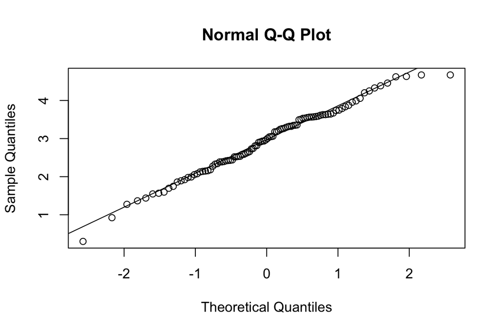

```r
# Syntax: r + distribution name in R
# It generates a given number of random numbers from specified distribution

# Randomly generate 100 samples following normal distribution with mean 3 and standard deviation 1
x1 <- rnorm(n=100, mean=3, sd=1)
qqnorm(x1) #  plot normal qq plot
qqline(x1) #  add a reference line to the qq plot
```

```r
# Generating 100 random numbers with F distribution df1=2 and df=5
x2 = rf(100,df1=2,df=5)
```

## Given x, generate $$y=(x+5)^{(e^{1.3}+N(0,0.1))}$$

```r
x=seq(0.1,10,0.1)
set.seed(2022)
rand = rnorm(100,0,0.1)
y = (x+5)^(exp(1.3)+rand)
cor(x,y)
```

```
## [1] 0.8596957
```

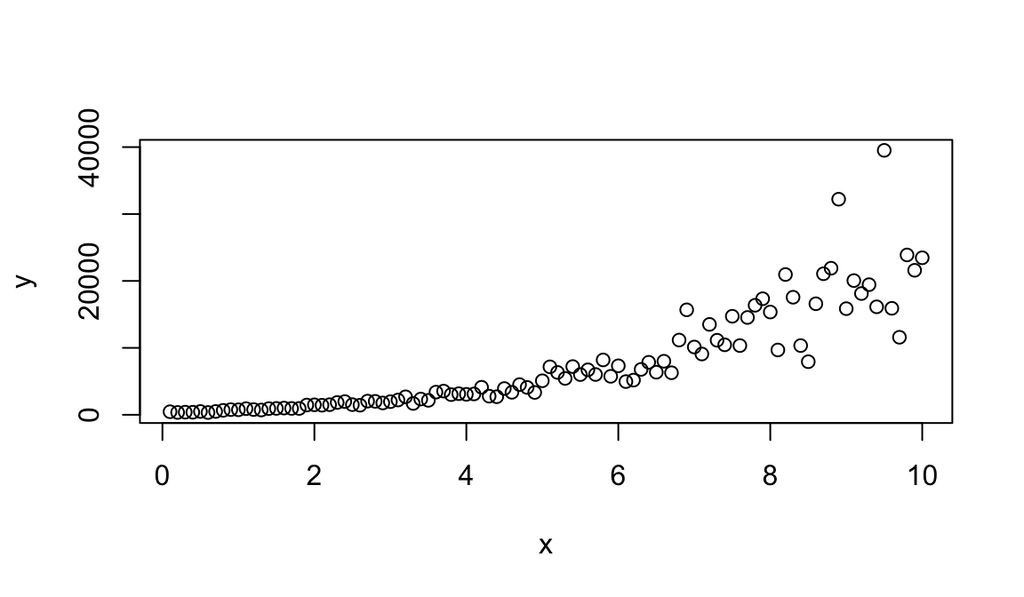

```r
plot(x,y)
```

### Basic Visualization histogram & Boxplot

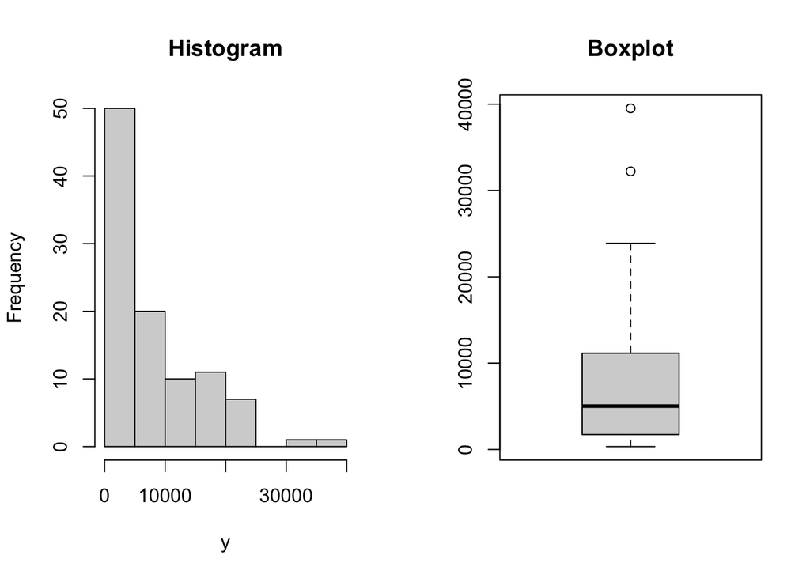

```r
par(mfrow=c(1,2))
hist(y, main = "Histogram")
boxplot(y, main = "Boxplot")
```

### Plot the data with fitted line

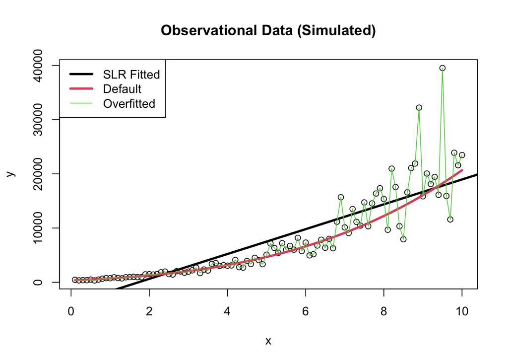

```r
par(mfrow=c(1,1))
plot(x,y, pch=1, main="Observational Data (Simulated)")
fit1 = lm(y~x)
abline(fit1$coefficients,lwd=3, col=1)
yhat = (x+5)^(exp(1.3))
lines(x,yhat, lwd=3,  col=2)
lines(x,y, lwd=1, col=3)
legend('topleft', c("SLR Fitted","Default","Overfitted"), lwd=c(3,3,1), col=c(1,2,3))
```

# Example Dataset

```r
library(MASS)
help(cats)
```

This data frame contains the following columns: # Sex: Factor with levels “F” and “M”. Bwt: body weight in kg. Hwt: heart weight in g. It is always a good idea to take a look of the data # (if it’s not too large).

You can always summaries a dataset to find the basic statistics

```r
attach(cats)
summary(cats)
```

```
##  Sex         Bwt             Hwt
##  F:47   Min.   :2.000   Min.   : 6.30
##  M:97   1st Qu.:2.300   1st Qu.: 8.95
##         Median :2.700   Median :10.10
##         Mean   :2.724   Mean   :10.63
##         3rd Qu.:3.025   3rd Qu.:12.12
##         Max.   :3.900   Max.   :20.50
```

Check how the dataset looks like.

```r
dim(cats)
```

```
## [1] 144   3
```

```r
head(cats)
```

|  | Sex | Bwt | Hwt |
| --- | --- | --- | --- |
| 1 | F | 2.0 | 7.0 |
| 2 | F | 2.0 | 7.4 |
| 3 | F | 2.0 | 9.5 |
| 4 | F | 2.1 | 7.2 |
| 5 | F | 2.1 | 7.3 |
| 6 | F | 2.1 | 7.6 |

```r
tail(cats)
```

|  | Sex | Bwt | Hwt |
| --- | --- | --- | --- |
| 139 | M | 3.6 | 15.0 |
| 140 | M | 3.7 | 11.0 |
| 141 | M | 3.8 | 14.8 |
| 142 | M | 3.8 | 16.8 |
| 143 | M | 3.9 | 14.4 |
| 144 | M | 3.9 | 20.5 |

```r
names(cats)
```

```
## [1] "Sex" "Bwt" "Hwt"
```

```r
class(Bwt)
```

```
## [1] "numeric"
```

```r
class(Hwt)
```

```
## [1] "numeric"
```

```r
class(Sex)
```

```
## [1] "factor"
```

The following are some useful functions

```r
sub1 = subset(cats, Sex=='F')
sub2 = subset(cats, Bwt<=2.2)
sub3 = subset(cats, (Bwt<=2.5 & Hwt>=10))
mean(Bwt)
```

```
## [1] 2.723611
```

```r
var(Bwt)
```

```
## [1] 0.2355225
```

```r
sd(Bwt)
```

```
## [1] 0.4853066
```

```r
sqrt(var(Bwt))
```

```
## [1] 0.4853066
```

```r
sort(Bwt)
```

```
##   [1] 2.0 2.0 2.0 2.0 2.0 2.1 2.1 2.1 2.1 2.1 2.1 2.1 2.1 2.1 2.1 2.2 2.2 2.2
##  [19] 2.2 2.2 2.2 2.2 2.2 2.2 2.2 2.2 2.2 2.2 2.2 2.3 2.3 2.3 2.3 2.3 2.3 2.3
##  [37] 2.3 2.3 2.3 2.3 2.3 2.3 2.4 2.4 2.4 2.4 2.4 2.4 2.4 2.4 2.4 2.5 2.5 2.5
##  [55] 2.5 2.5 2.5 2.5 2.5 2.5 2.5 2.6 2.6 2.6 2.6 2.6 2.6 2.6 2.6 2.6 2.7 2.7
##  [73] 2.7 2.7 2.7 2.7 2.7 2.7 2.7 2.7 2.7 2.7 2.8 2.8 2.8 2.8 2.8 2.8 2.8 2.9
##  [91] 2.9 2.9 2.9 2.9 2.9 2.9 2.9 3.0 3.0 3.0 3.0 3.0 3.0 3.0 3.0 3.0 3.0 3.0
## [109] 3.1 3.1 3.1 3.1 3.1 3.1 3.2 3.2 3.2 3.2 3.2 3.2 3.3 3.3 3.3 3.3 3.3 3.4
## [127] 3.4 3.4 3.4 3.4 3.5 3.5 3.5 3.5 3.5 3.6 3.6 3.6 3.6 3.7 3.8 3.8 3.9 3.9
```

Do some basic plot, e.g. histogram & boxplot of Bwt & Hwt

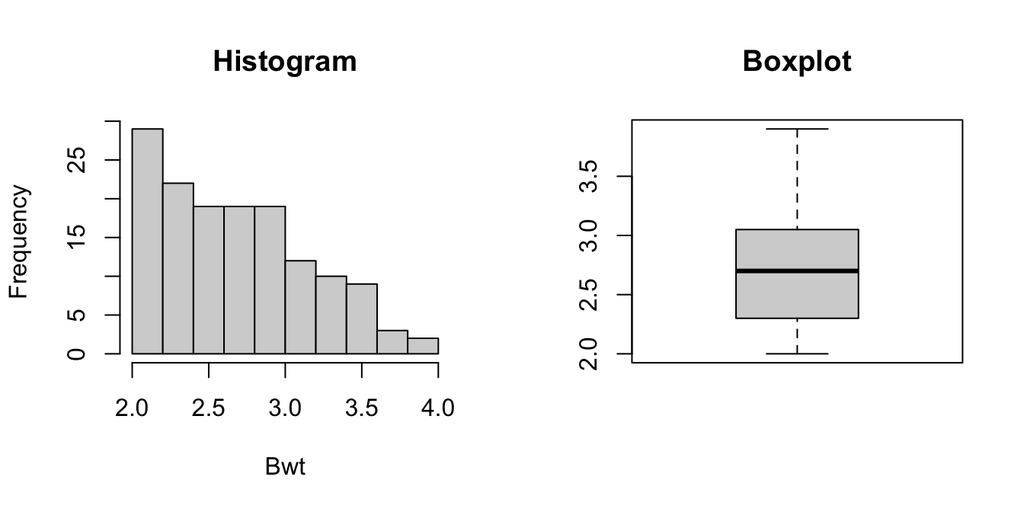

```r
par(mfrow=c(1,2))
hist(Bwt, main = "Histogram")
boxplot(Bwt, main = "Boxplot")
```

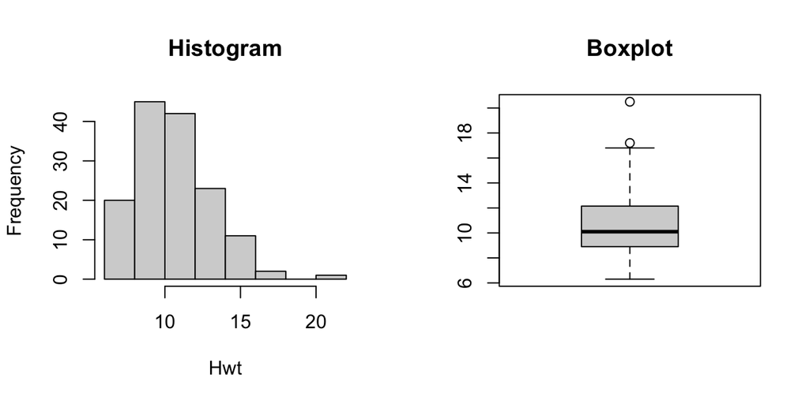

```r
par(mfrow=c(1,2))
hist(Hwt, main = "Histogram")
boxplot(Hwt, main = "Boxplot")
```

Do the basic scatterplot

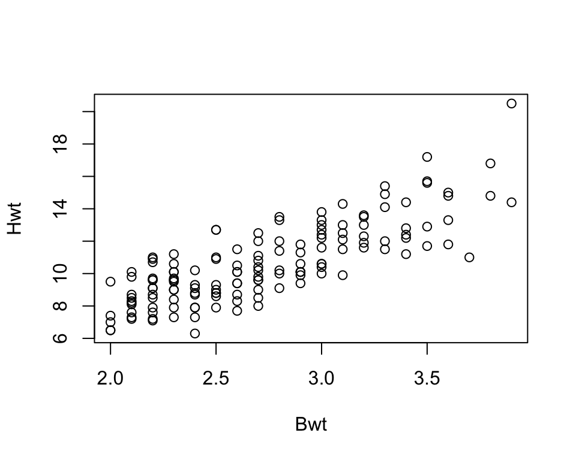

```r
plot(Bwt, Hwt)
```

What about personalize your plot

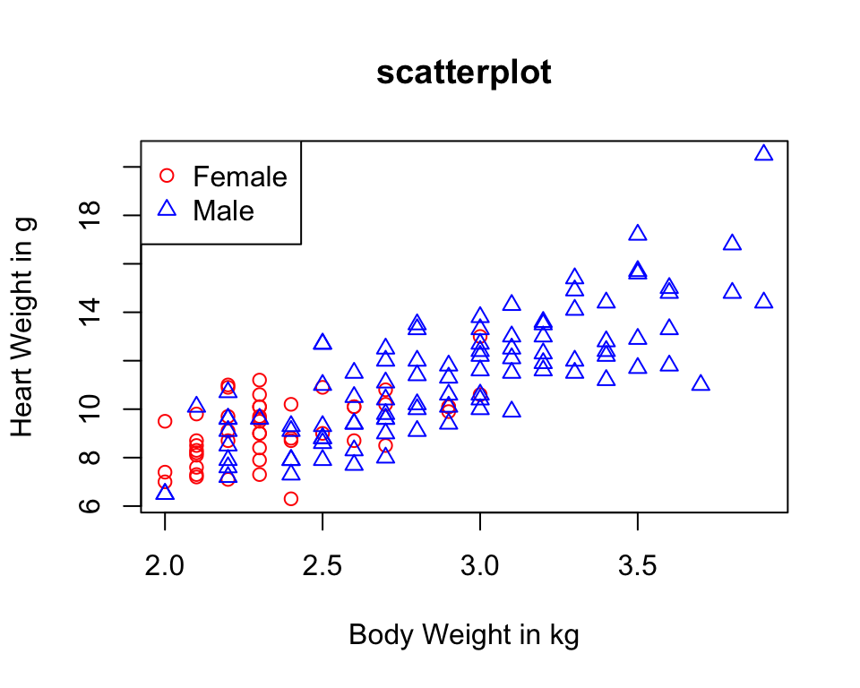

```r
plot(Bwt, Hwt, xlab = "Body Weight in kg", ylab="Heart Weight in g",
main="scatterplot", type='n')
points(Bwt[Sex=='F'], Hwt[Sex=='F'], col="red", pch=1, cex=1) # cex: size, pch: symbols
points(Bwt[Sex=='M'], Hwt[Sex=='M'], col="blue", pch=2, cex=1)
legend("topleft",cex=1, legend= c("Female","Male"), col=c("red", "blue"), pch=c(1,2))
```

Build up a simple linear regression model to Heart weight and Body weight

```r
mod=lm(Hwt~Bwt,data=cats)
summary(mod)
```

```
##
## Call:
## lm(formula = Hwt ~ Bwt, data = cats)
##
## Residuals:
##     Min      1Q  Median      3Q     Max
## -3.5694 -0.9634 -0.0921  1.0426  5.1238
##
## Coefficients:
##             Estimate Std. Error t value Pr(>|t|)
## (Intercept)  -0.3567     0.6923  -0.515    0.607
## Bwt           4.0341     0.2503  16.119   <2e-16 ***
## ---
## Signif. codes:  0 '***' 0.001 '**' 0.01 '*' 0.05 '.' 0.1 ' ' 1
##
## Residual standard error: 1.452 on 142 degrees of freedom
## Multiple R-squared:  0.6466, Adjusted R-squared:  0.6441
## F-statistic: 259.8 on 1 and 142 DF,  p-value: < 2.2e-16
```

Look at the attributes in the model

```r
attributes(mod)
```

```
## $names
##  [1] "coefficients"  "residuals"     "effects"       "rank"
##  [5] "fitted.values" "assign"        "qr"            "df.residual"
##  [9] "xlevels"       "call"          "terms"         "model"
##
## $class
## [1] "lm"
```

```r
mod$coefficients
```

```
## (Intercept)         Bwt
##  -0.3566624   4.0340627
```

Find the confidence intervals of the coefficients

```r
confint(mod)
```

```
##                 2.5 %   97.5 %
## (Intercept) -1.725163 1.011838
## Bwt          3.539343 4.528782
```

```r
confint(mod, level=0.99)
```

```
##                 0.5 %   99.5 %
## (Intercept) -2.164125 1.450800
## Bwt          3.380656 4.687469
```

Plot the fitted line to the points

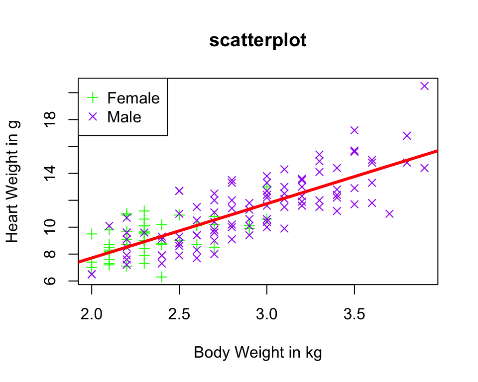

```r
plot(Bwt, Hwt, xlab = "Body Weight in kg", ylab="Heart Weight in g",
main="scatterplot", type='n')
points(Bwt[Sex=='F'], Hwt[Sex=='F'], col="green", pch=3, cex=1)
points(Bwt[Sex=='M'], Hwt[Sex=='M'], col="purple", pch=4, cex=1)
legend("topleft",cex=1, legend= c("Female","Male"), col=c("green", "purple"), pch=c(3,4))
abline(mod, col='red',lwd=3)
```